# Decision Tree Lab

Maxwell St. John, Helena Lindsay, Allen Baiju

November 18, 2020

Congrats! You just graduated from medical school and got a PhD in Data Science at the same time, wow impressive. Because of these incredible accomplishments the world now believes you will be able to cure cancer…no pressure. To start you figured you better create some way to detect cancer when present. Luckily because you are now a MD and DS PhD or MDSDPhD, you have access to data sets and know your way around a ML classifier. So, on the way to fulfilling your destiny to rid the world of cancer you start by building several classifiers that can be used to aid in determining if patients have cancer and the type of tumor.

The included dataset (clinical_data_breast_cancer_modified.csv) has information on 105 patients across 20 variables, your goal is to build two classifiers one for PR.Status (progesterone receptor), a biomarker that routinely leads to a cancer diagnosis, indicating if there was a positive or negative outcome and one for the Tumor multi-class variable . You would like to be able to explain the model to the mere mortals around you but need a fairly robust and flexible approach so you’ve chosen to use decision trees to get started and will possibly move to a ensemble model if needed.

In doing so, similar to great data scientists working at very average marketing firms, you remembered the excellent education provided to you at UVA in a undergrad data science course and have outlined 20ish steps that will need to be undertaken to complete this task (you can add more or combine if needed). As always, you will need to make sure to #comment your work heavily and render the results in a clear report (knitted) as the non MDSDPhDs of the world will someday need to understand the wonder and spectacle that will be your R code. Good luck and the world thanks you.

Footnotes: - Some of the steps will not need to be repeated for the second model, use your judgment - You can add or combine steps if needed - Also, remember to try several methods during evaluation and always be mindful of how the model will be used in practice.

```r
#1 Load the data and ensure the column names don't have spaces, hint check.names.
data <- tibble(import("clinical_breast_cleaned.csv", check.names= TRUE))
```

# Models

## PR.Status

```r
# Base rate
PR_data_base_rate = sum(data$PR.Status)/length(data$PR.Status)
PR_data_base_rate
```

```
## [1] 0.5142857
```

The base rate was 0.514.

```
## n= 105
##
## node), split, n, loss, yval, (yprob)
##       * denotes terminal node
##
##  1) root 105 51 Positive (0.4857143 0.5142857)
##    2) Days.to.Date.of.Last.Contact< 12 17  4 Negative (0.7647059 0.2352941) *
##    3) Days.to.Date.of.Last.Contact>=12 88 38 Positive (0.4318182 0.5681818)
##      6) AJCC.Stage=IB,IIA,III,IV 29 11 Negative (0.6206897 0.3793103)
##       12) OS.Time< 1144.5 17  4 Negative (0.7647059 0.2352941) *
##       13) OS.Time>=1144.5 12  5 Positive (0.4166667 0.5833333) *
##      7) AJCC.Stage=I,IA,II,IIB,IIIA,IIIB,IIIC 59 20 Positive (0.3389831 0.6610169)
##       14) Age.at.Initial.Pathologic.Diagnosis< 57 28 13 Positive (0.4642857 0.5357143)
##         28) AJCC.Stage=I,II,IIIB,IIIC 9  2 Negative (0.7777778 0.2222222) *
##         29) AJCC.Stage=IA,IIB,IIIA 19  6 Positive (0.3157895 0.6842105) *
##       15) Age.at.Initial.Pathologic.Diagnosis>=57 31  7 Positive (0.2258065 0.7741935) *
```

Above is the model we built. The most important variables are Days.to.Date.of.Last.Contact, AJCC.Stage, and OS.Time.

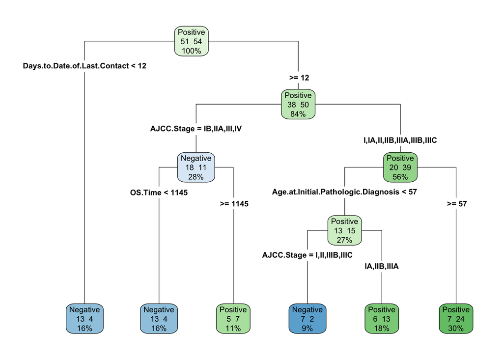

```r
#9 Plot the tree using the rpart.plot package
rpart.plot(PR_data_tree_gini, type =4, extra = 101)
```

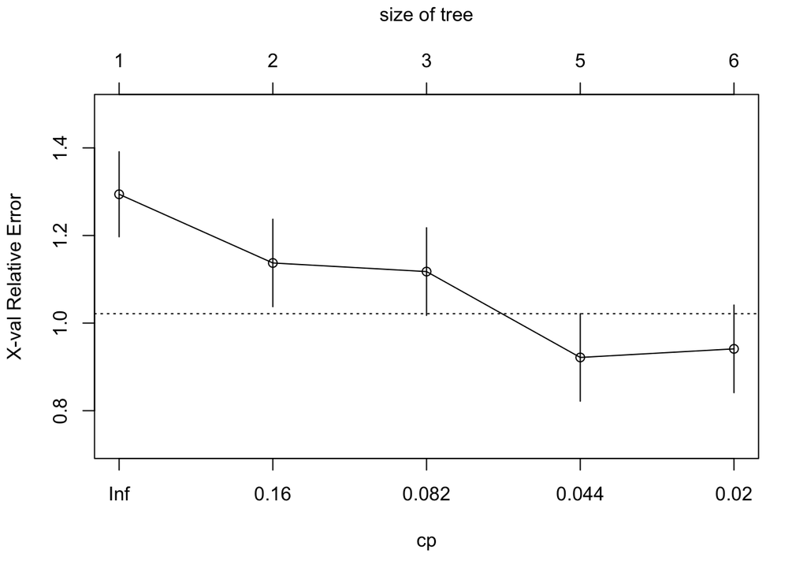

```r
#10 plot and convert the table to a data.frame
plotcp(PR_data_tree_gini)
```

```r
cptable_ex <- as_tibble(PR_data_tree_gini$cptable, )
```

|  | Negative | Positive |
| --- | --- | --- |
| Negative | 33 | 10 |
| Positive | 18 | 44 |

```
## # A tibble: 1 x 3
##   hit_rate detection_rate base_rate
##      <dbl>          <dbl>     <dbl>
## 1    0.267          0.419     0.514
```

The hit rate was 0.267 while the detection rate was 0.419. The detection rate was lower than the base rate we calculated previously (0.514).

```r
#15 Use the the confusion matrix function to check a variety of metrics and comment on the metric that might be best for this type of analysis.
PR_data_conf_matrix_func <- confusionMatrix(PR_data_fitted_model, PR_data$PR.Status, positive = "Positive", dnn=c("Prediction", "Actual"), mode = "sens_spec")
PR_data_conf_matrix_func
```

```
## Confusion Matrix and Statistics
##
##           Actual
## Prediction Negative Positive
##   Negative       33       10
##   Positive       18       44
##
##                Accuracy : 0.7333
##                  95% CI : (0.6381, 0.8149)
##     No Information Rate : 0.5143
##     P-Value [Acc > NIR] : 3.715e-06
##
##                   Kappa : 0.4639
##
##  Mcnemar's Test P-Value : 0.1859
##
##             Sensitivity : 0.8148
##             Specificity : 0.6471
##          Pos Pred Value : 0.7097
##          Neg Pred Value : 0.7674
##              Prevalence : 0.5143
##          Detection Rate : 0.4190
##    Detection Prevalence : 0.5905
##       Balanced Accuracy : 0.7309
##
##        'Positive' Class : Positive
##
```

From these metrics, we can draw a few conclusions. First, since our model has a higher sensitivity value (0.8148) than specificity value (0.6471) we know our model is better at identifying subjects that are cancer-positive than negative. The accuracy of our model was calculated to be 0.7333.

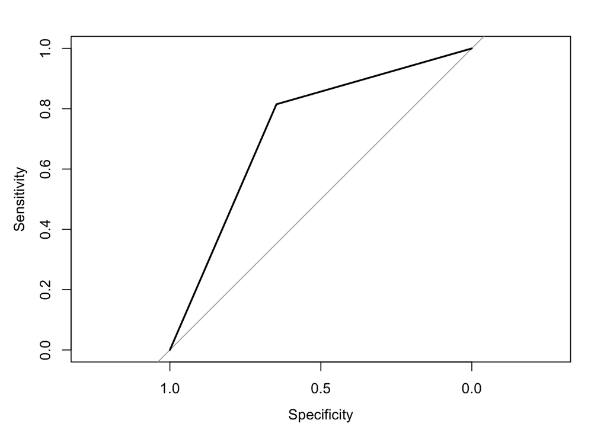

```r
#16 Generate a ROC and AUC output, interpret the results
PR_data_ROC <- roc(PR_data$PR.Status, as.numeric(PR_data_fitted_model), plot = TRUE)
```

```r
PR_data_ROC$auc
```

```
## Area under the curve: 0.7309
```

Since the AUC value of 0.7309 is high, we can conclude that there is a 73.09% chance that our model accurately identifies cancer.

### Modifications

#### Threshold

##### Threshold = 0.5

```
## Confusion Matrix and Statistics
##
##           Actual
## Prediction Negative Positive
##   Negative       33       10
##   Positive       18       44
##
##                Accuracy : 0.7333
##                  95% CI : (0.6381, 0.8149)
##     No Information Rate : 0.5143
##     P-Value [Acc > NIR] : 3.715e-06
##
##                   Kappa : 0.4639
##
##  Mcnemar's Test P-Value : 0.1859
##
##             Sensitivity : 0.8148
##             Specificity : 0.6471
##          Pos Pred Value : 0.7097
##          Neg Pred Value : 0.7674
##               Precision : 0.7097
##                  Recall : 0.8148
##                      F1 : 0.7586
##              Prevalence : 0.5143
##          Detection Rate : 0.4190
##    Detection Prevalence : 0.5905
##       Balanced Accuracy : 0.7309
##
##        'Positive' Class : Positive
##
```

```
## Sensitivity Sensitivity Sensitivity Sensitivity Sensitivity
##   0.8148148   0.8148148   0.8148148   0.6851852   0.4444444
```

#### Complexity Parameter (CP)

##### Complexity Parameter (CP) = 0.25

```
## Confusion Matrix and Statistics
##
##           Actual
## Prediction Negative Positive
##   Negative        0        0
##   Positive       51       54
##
##                Accuracy : 0.5143
##                  95% CI : (0.4147, 0.613)
##     No Information Rate : 0.5143
##     P-Value [Acc > NIR] : 0.5392
##
##                   Kappa : 0
##
##  Mcnemar's Test P-Value : 2.534e-12
##
##             Sensitivity : 1.0000
##             Specificity : 0.0000
##          Pos Pred Value : 0.5143
##          Neg Pred Value :    NaN
##              Prevalence : 0.5143
##          Detection Rate : 0.5143
##    Detection Prevalence : 1.0000
##       Balanced Accuracy : 0.5000
##
##        'Positive' Class : Positive
##
```

```
## Sensitivity
##           1
```

This makes the model predict exclusively positives since the included nodes are set to zero.

##### Complexity Parameter (CP) = 0.1

```
## Confusion Matrix and Statistics
##
##           Actual
## Prediction Negative Positive
##   Negative       13        4
##   Positive       38       50
##
##                Accuracy : 0.6
##                  95% CI : (0.4998, 0.6944)
##     No Information Rate : 0.5143
##     P-Value [Acc > NIR] : 0.04809
##
##                   Kappa : 0.1842
##
##  Mcnemar's Test P-Value : 3.543e-07
##
##             Sensitivity : 0.9259
##             Specificity : 0.2549
##          Pos Pred Value : 0.5682
##          Neg Pred Value : 0.7647
##              Prevalence : 0.5143
##          Detection Rate : 0.4762
##    Detection Prevalence : 0.8381
##       Balanced Accuracy : 0.5904
##
##        'Positive' Class : Positive
##
```

```
## Sensitivity
##   0.9259259
```

#### Minimum number of observations in any terminal

##### Minimum number of observations in any terminal = 15

```
## Confusion Matrix and Statistics
##
##           Actual
## Prediction Negative Positive
##   Negative       31       15
##   Positive       20       39
##
##                Accuracy : 0.6667
##                  95% CI : (0.568, 0.7557)
##     No Information Rate : 0.5143
##     P-Value [Acc > NIR] : 0.001126
##
##                   Kappa : 0.331
##
##  Mcnemar's Test P-Value : 0.498962
##
##             Sensitivity : 0.7222
##             Specificity : 0.6078
##          Pos Pred Value : 0.6610
##          Neg Pred Value : 0.6739
##              Prevalence : 0.5143
##          Detection Rate : 0.3714
##    Detection Prevalence : 0.5619
##       Balanced Accuracy : 0.6650
##
##        'Positive' Class : Positive
##
```

##### Minimum number of observations in any terminal = 5

```
## Confusion Matrix and Statistics
##
##           Actual
## Prediction Negative Positive
##   Negative       46        7
##   Positive        5       47
##
##                Accuracy : 0.8857
##                  95% CI : (0.8089, 0.9395)
##     No Information Rate : 0.5143
##     P-Value [Acc > NIR] : 5.384e-16
##
##                   Kappa : 0.7715
##
##  Mcnemar's Test P-Value : 0.7728
##
##             Sensitivity : 0.8704
##             Specificity : 0.9020
##          Pos Pred Value : 0.9038
##          Neg Pred Value : 0.8679
##              Prevalence : 0.5143
##          Detection Rate : 0.4476
##    Detection Prevalence : 0.4952
##       Balanced Accuracy : 0.8862
##
##        'Positive' Class : Positive
##
```

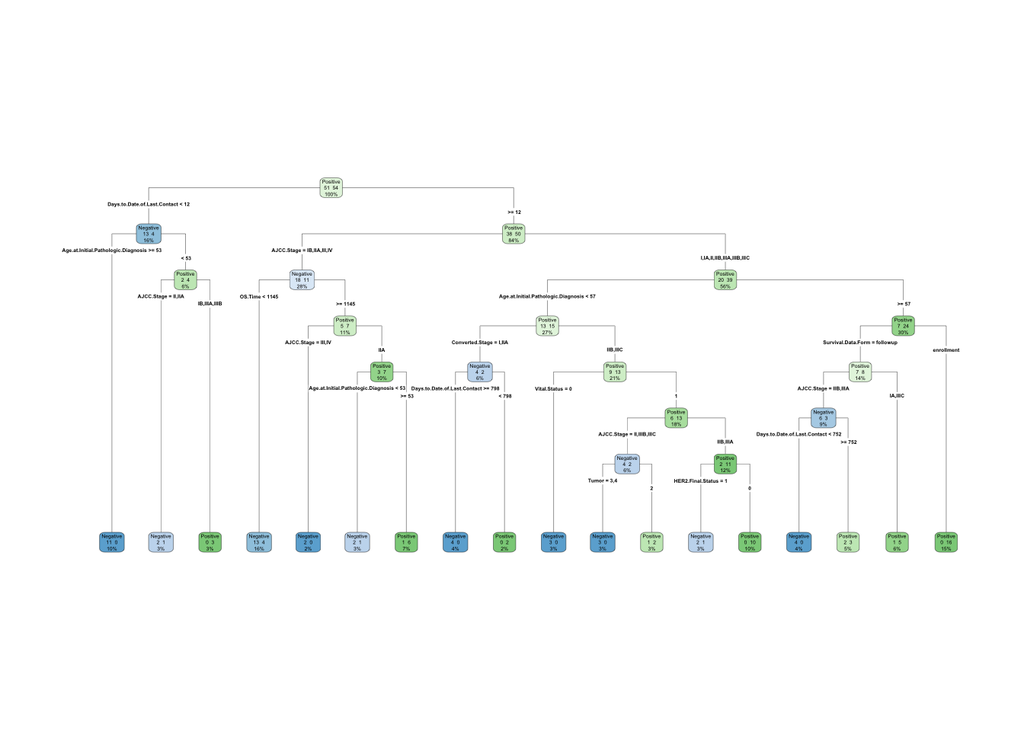

By adjusting the minimum number of observations in any terminal to 5, the sensitivity and specificity values are maximized thus far and the model accuracy is calculated to be 0.8857. The balanced accuracy (0.8862) is equivalent to the AUC value. This adjustment has significantly improved the prediction accuracy of our model.

## Tumor multi-class variable

```r
#1 base rates
data$Tumor <- as.factor(data$Tumor)

Tumor1_data_base_rate = sum(ifelse(data$Tumor == "1", 1,0))/length(data$Tumor)
Tumor2_data_base_rate = sum(ifelse(data$Tumor == "2", 1,0))/length(data$Tumor)
Tumor3_data_base_rate = sum(ifelse(data$Tumor == "3", 1,0))/length(data$Tumor)
Tumor4_data_base_rate = sum(ifelse(data$Tumor == "4", 1,0))/length(data$Tumor)
Tumor1_data_base_rate
```

```
## [1] 0.1428571
```

```r
Tumor2_data_base_rate
```

```
## [1] 0.6190476
```

```r
Tumor3_data_base_rate
```

```
## [1] 0.1809524
```

```r
Tumor4_data_base_rate
```

```
## [1] 0.05714286
```

```r
#3 View the results, what is the most important variable for the tree?
Tumor_data_tree_gini
```

```
## n= 105
##
## node), split, n, loss, yval, (yprob)
##       * denotes terminal node
##
##  1) root 105 40 2 (0.14285714 0.61904762 0.18095238 0.05714286)
##    2) AJCC.Stage=I,IA,IIIB 16  6 1 (0.62500000 0.00000000 0.00000000 0.37500000) *
##    3) AJCC.Stage=IB,II,IIA,IIB,III,IIIA,IIIC,IV 89 24 2 (0.05617978 0.73033708 0.21348315 0.00000000)
##      6) AJCC.Stage=IB,II,IIA,III 46  4 2 (0.08695652 0.91304348 0.00000000 0.00000000) *
##      7) AJCC.Stage=IIB,IIIA,IIIC,IV 43 20 2 (0.02325581 0.53488372 0.44186047 0.00000000)
##       14) Node.Coded=1 33 11 2 (0.03030303 0.66666667 0.30303030 0.00000000)
##         28) AJCC.Stage=IIB 13  0 2 (0.00000000 1.00000000 0.00000000 0.00000000) *
##         29) AJCC.Stage=IIIA,IIIC,IV 20 10 3 (0.05000000 0.45000000 0.50000000 0.00000000)
##           58) Days.to.Date.of.Last.Contact>=473.5 10  3 2 (0.00000000 0.70000000 0.30000000 0.00000000) *
##           59) Days.to.Date.of.Last.Contact< 473.5 10  3 3 (0.10000000 0.20000000 0.70000000 0.00000000) *
##       15) Node.Coded=0 10  1 3 (0.00000000 0.10000000 0.90000000 0.00000000) *
```

AJCC.Stage is the most important variable.

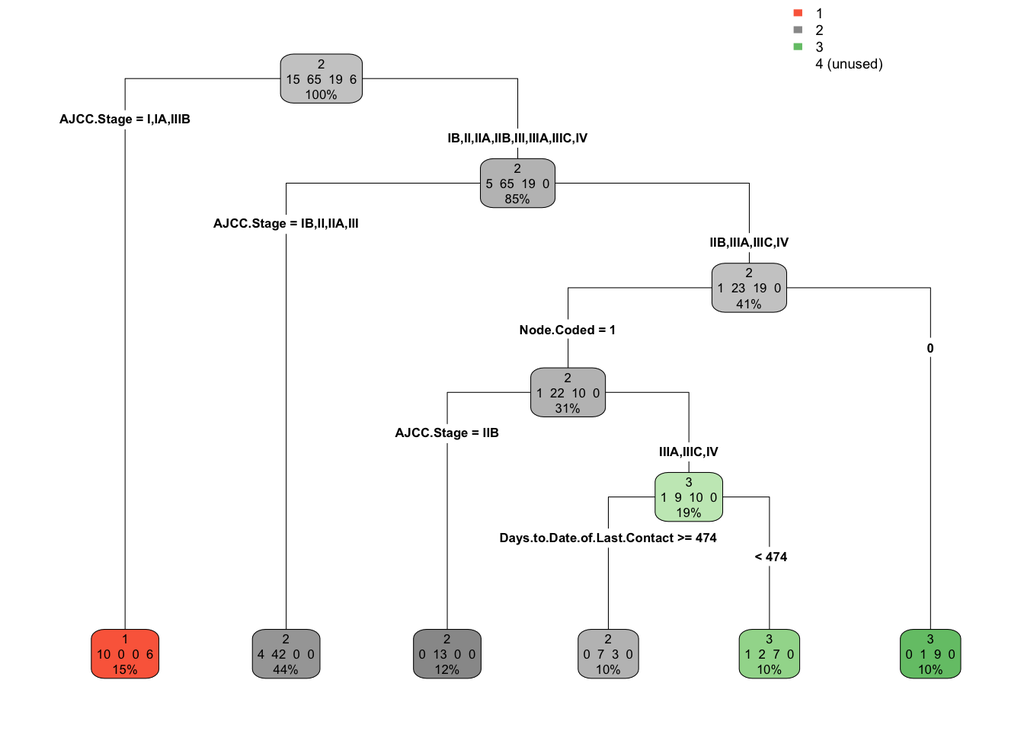

```r
#4 Plot the tree using the rpart.plot package
rpart.plot(Tumor_data_tree_gini, type =4, extra = 101)
```

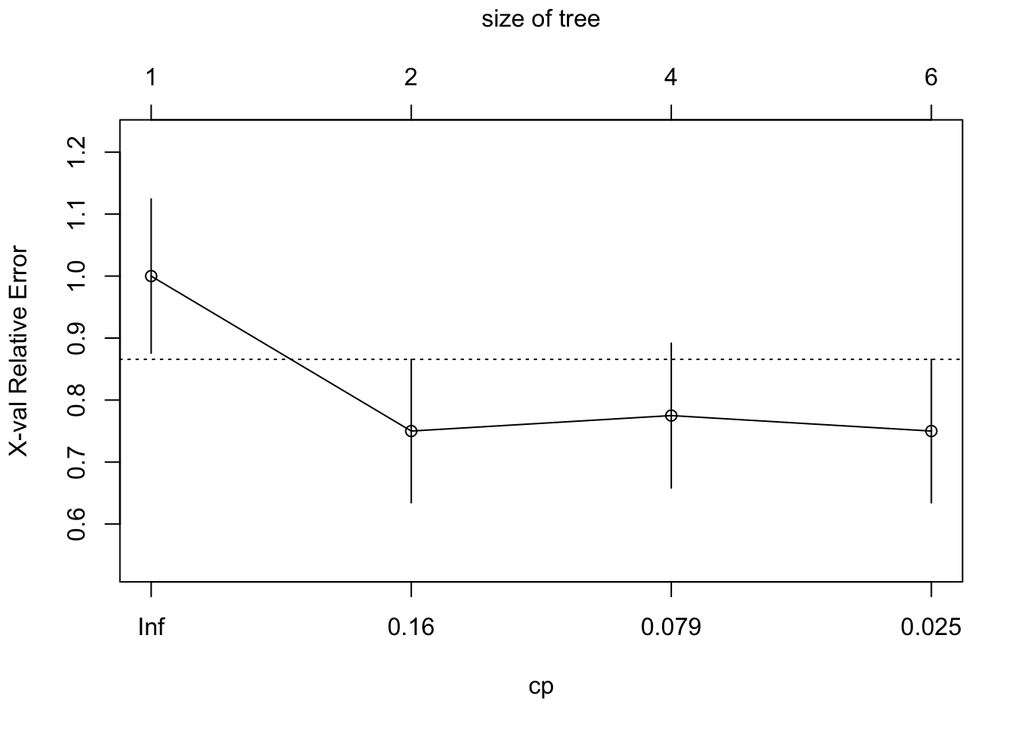

```r
#5 plot and convert the table to a data.frame
plotcp(Tumor_data_tree_gini)
```

```r
#7 Use the predict function and your model to predict the target variable.
Tumor_data_fitted_model = predict(Tumor_data_tree_gini, type= "class")
table(Tumor_data_fitted_model)
```

```
## Tumor_data_fitted_model
##  1  2  3  4
## 16 69 20  0
```

```r
#9 Use the the confusion matrix function to check a variety of metrics and comment on the metric that might be best for this type of analysis.
confusionMatrix(Tumor_data_conf_matrix)
```

```
## Confusion Matrix and Statistics
##
##
## Tumor_data_fitted_model  1  2  3  4
##                       1 10  0  0  6
##                       2  4 62  3  0
##                       3  1  3 16  0
##                       4  0  0  0  0
##
## Overall Statistics
##
##                Accuracy : 0.8381
##                  95% CI : (0.7535, 0.9028)
##     No Information Rate : 0.619
##     P-Value [Acc > NIR] : 8.26e-07
##
##                   Kappa : 0.6985
##
##  Mcnemar's Test P-Value : NA
##
## Statistics by Class:
##
##                      Class: 1 Class: 2 Class: 3 Class: 4
## Sensitivity           0.66667   0.9538   0.8421  0.00000
## Specificity           0.93333   0.8250   0.9535  1.00000
## Pos Pred Value        0.62500   0.8986   0.8000      NaN
## Neg Pred Value        0.94382   0.9167   0.9647  0.94286
## Prevalence            0.14286   0.6190   0.1810  0.05714
## Detection Rate        0.09524   0.5905   0.1524  0.00000
## Detection Prevalence  0.15238   0.6571   0.1905  0.00000
## Balanced Accuracy     0.80000   0.8894   0.8978  0.50000
```

The sensitivity and specificity metrics provide us with information regarding how the model classifies a subject as positive or negative. The accuracy (0.8381) is also an important metric for our analysis. Unfortunately, our model fails to correctly predict tumors of the fourth class.

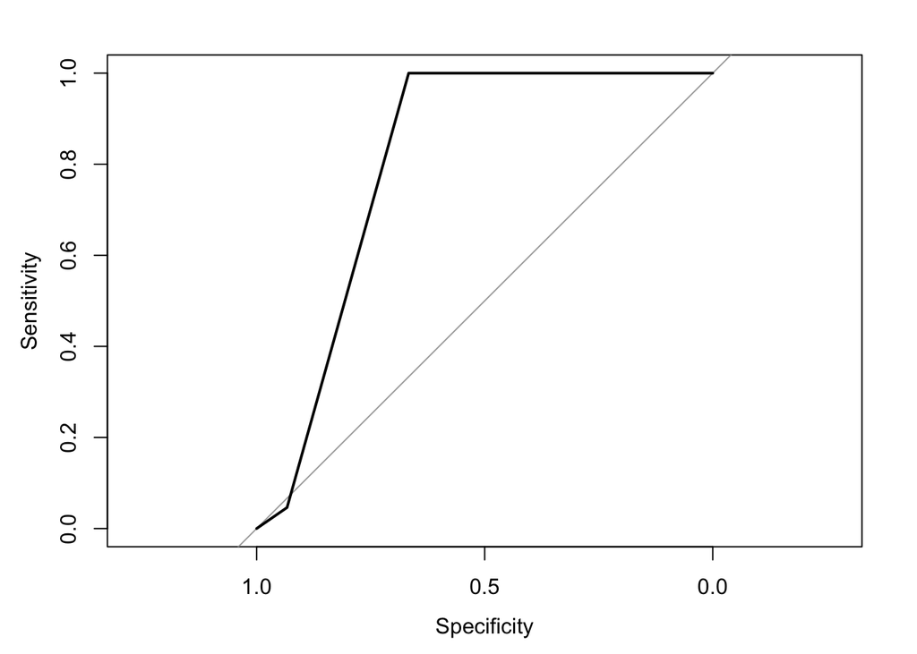

```r
#10 Generate a ROC and AUC output, interpret the results
Tumor_data_ROC <- roc(Tumor_data$Tumor, as.numeric(Tumor_data_fitted_model), plot = TRUE)
```

```r
Tumor_data_ROC$auc
```

```
## Area under the curve: 0.8077
```

This ROC curve yields an AUC of approximately 0.8077. This model is highly capable of distinguishing between the classes.

### Modifications

#### Threshold= 0.35 for each class

##### Class1

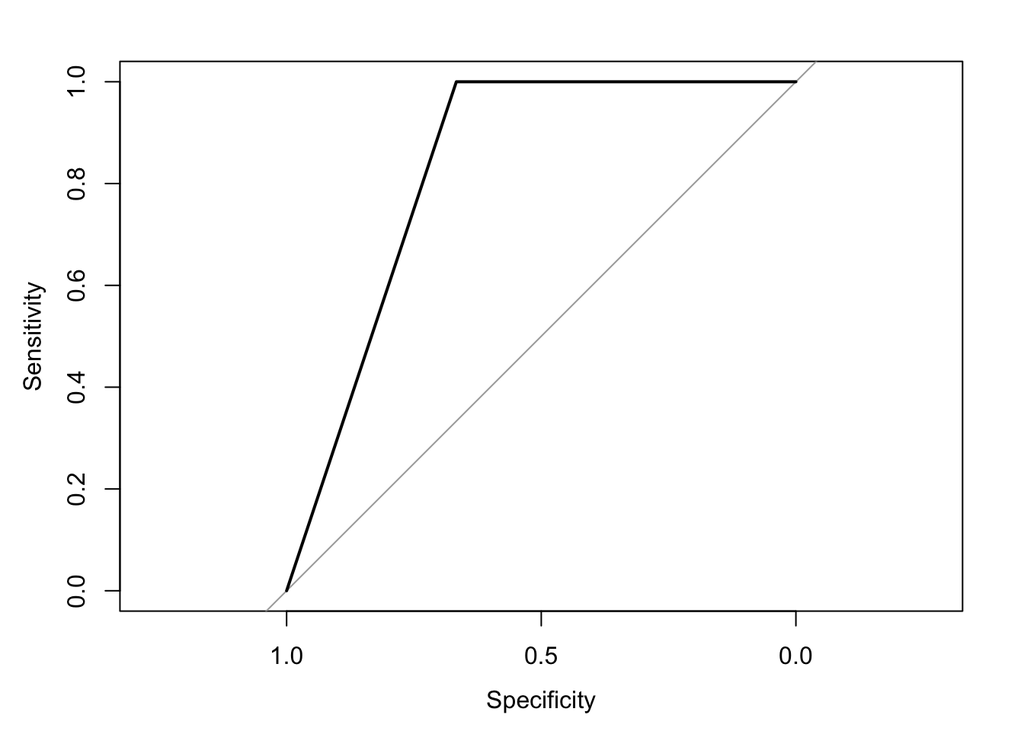

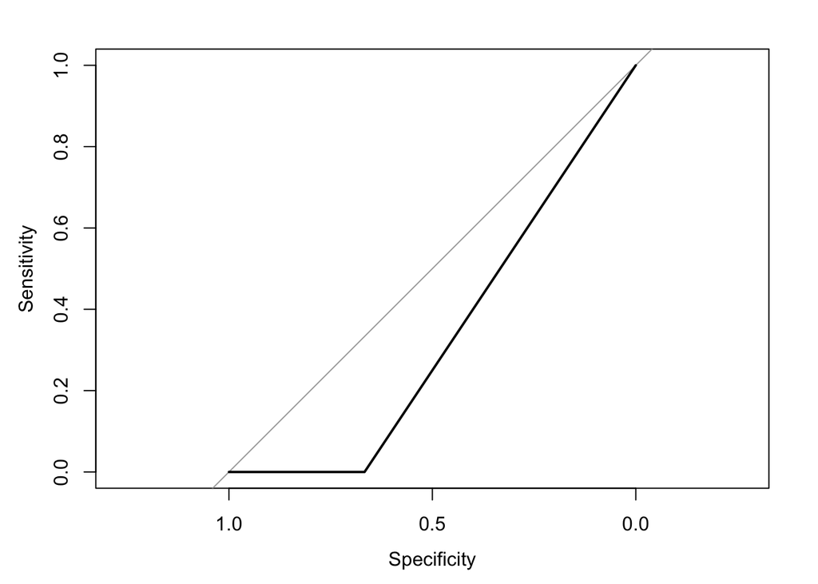

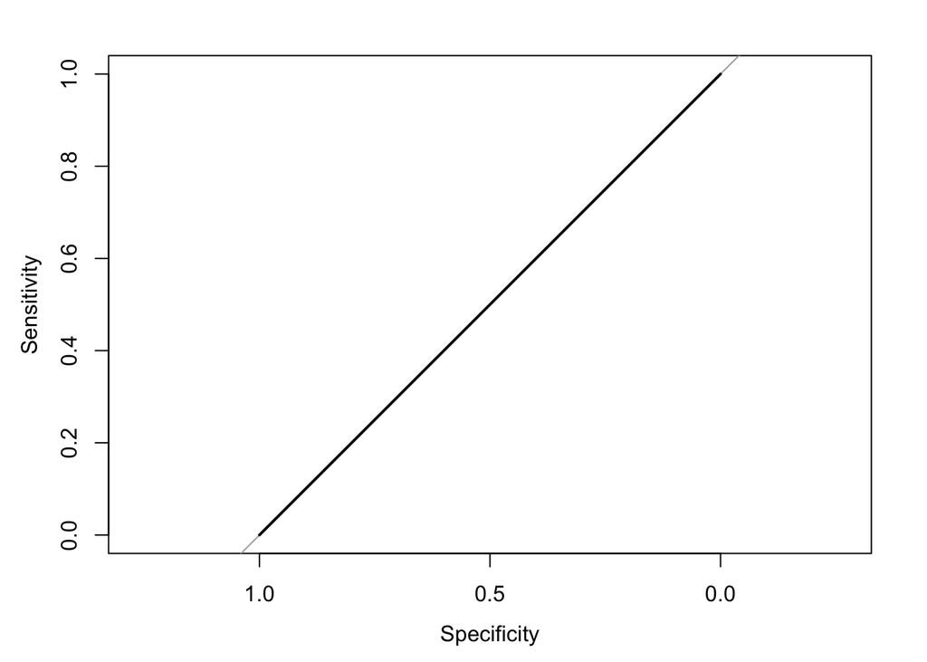

```
##
## Call:
## multiclass.roc.default(response = data$Tumor, predictor = ifelse(Tumor_data_fitted_prob[,     "1"] >= 0.35, 0, 1), plot = TRUE)
##
## Data: ifelse(Tumor_data_fitted_prob[, "1"] >= 0.35, 0, 1) with 4 levels of data$Tumor: 1, 2, 3, 4.
## Multi-class area under the curve: 0.75
```

```r
multiclass.roc(data$Tumor, ifelse(Tumor_data_fitted_prob[, '1'] >= .35, 0, 1), plot = TRUE)
```

##### Class2

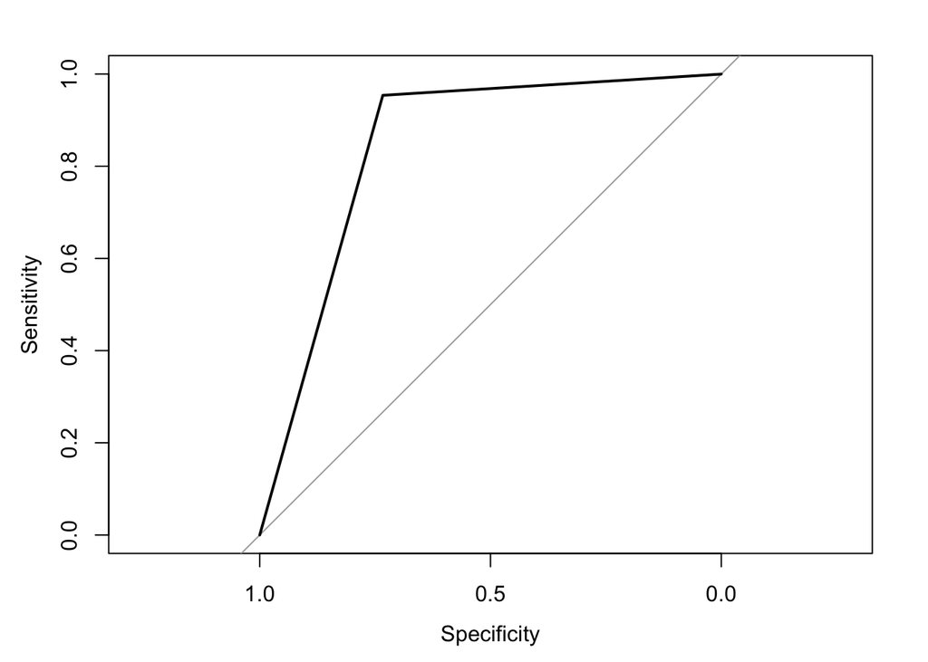

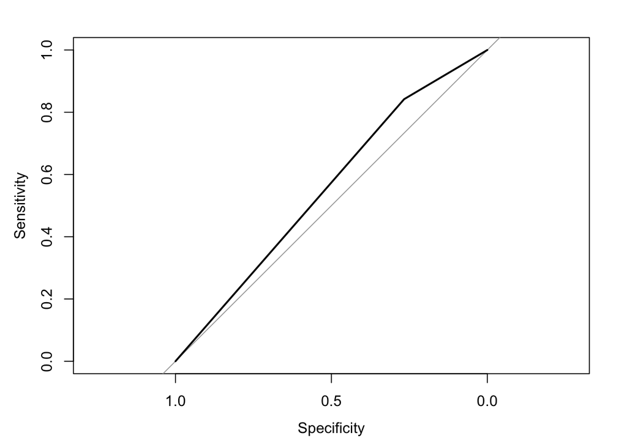

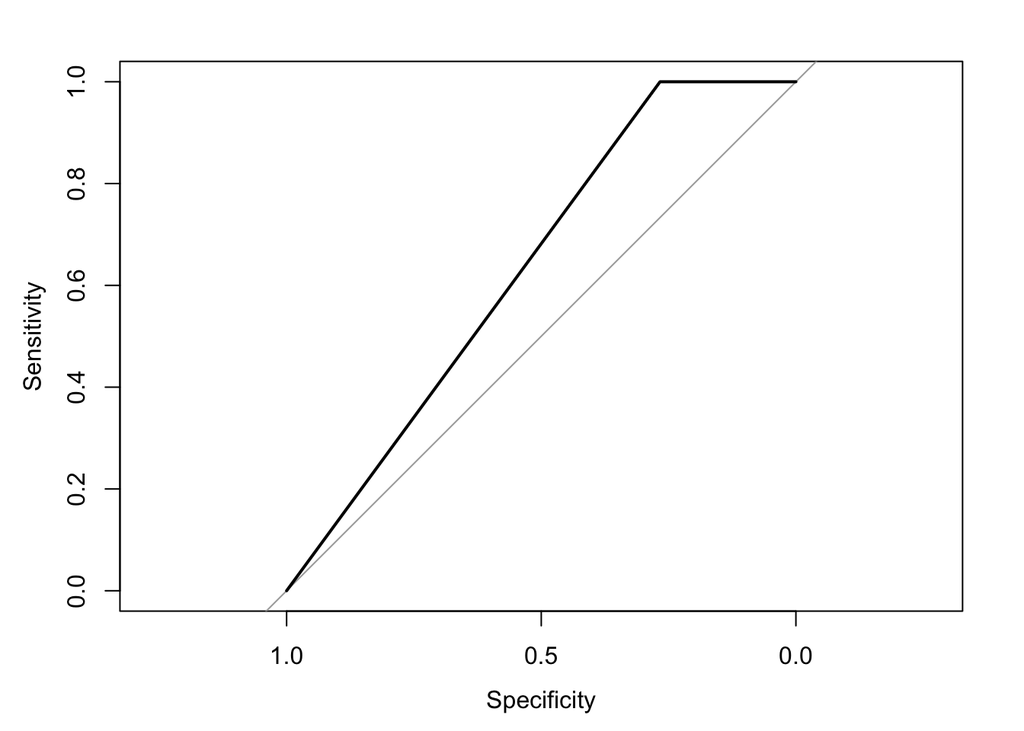

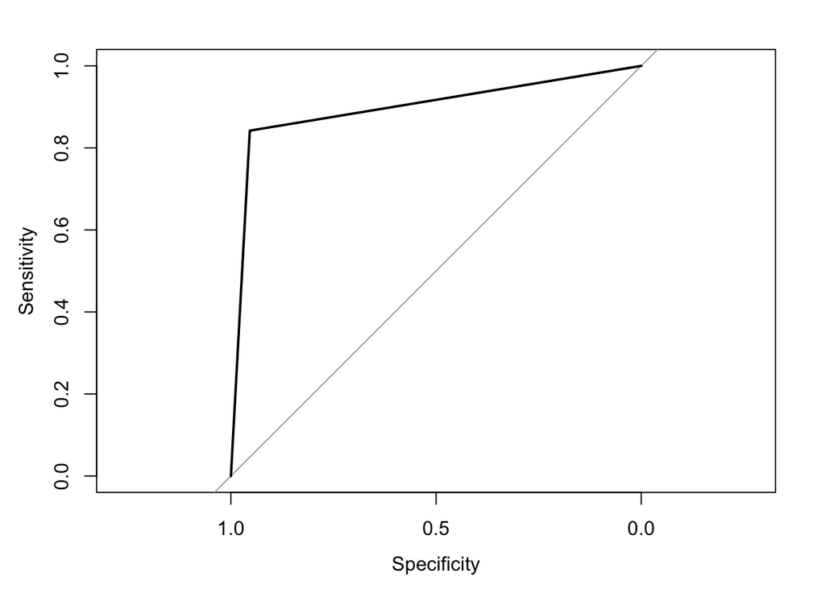

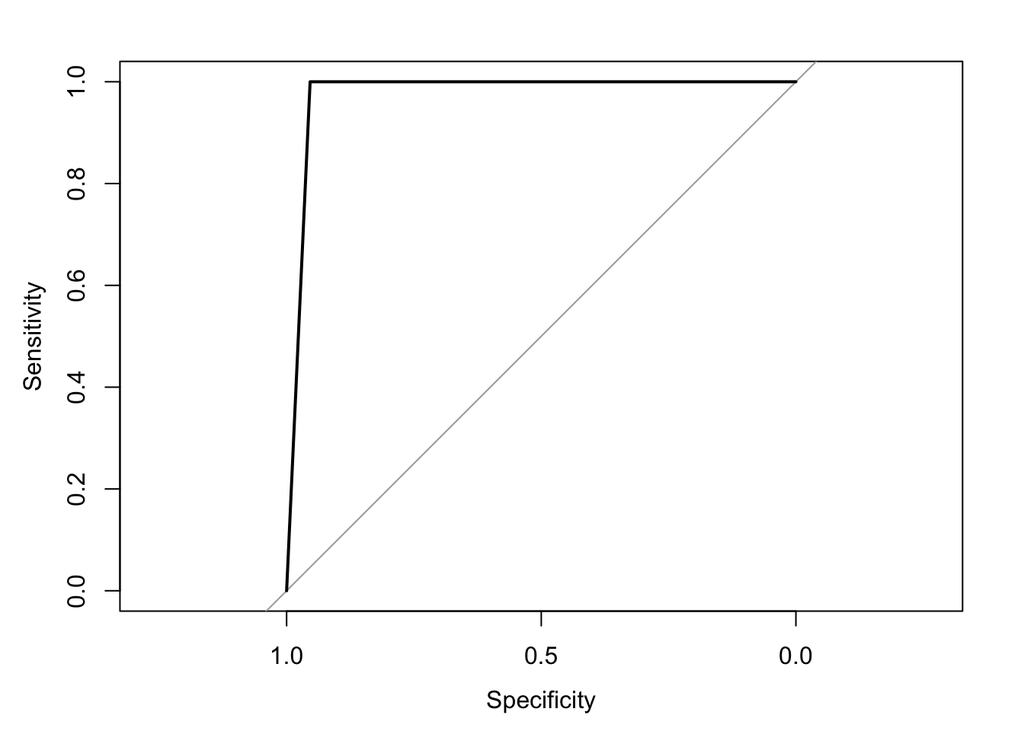

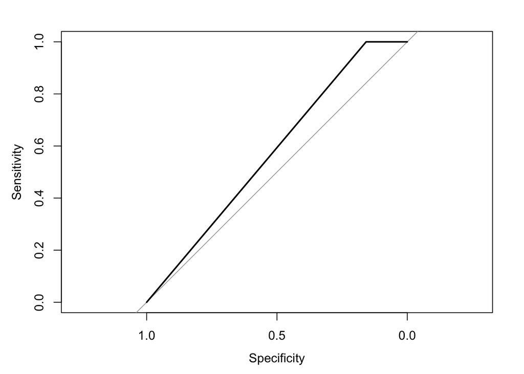

```
##
## Call:
## multiclass.roc.default(response = data$Tumor, predictor = ifelse(Tumor_data_fitted_prob[,     "2"] >= 0.35, 0, 1), plot = TRUE)
##
## Data: ifelse(Tumor_data_fitted_prob[, "2"] >= 0.35, 0, 1) with 4 levels of data$Tumor: 1, 2, 3, 4.
## Multi-class area under the curve: 0.7475
```

```r
multiclass.roc(data$Tumor, ifelse(Tumor_data_fitted_prob[, '2'] >= .35, 0, 1), plot = TRUE)
```

##### Class3

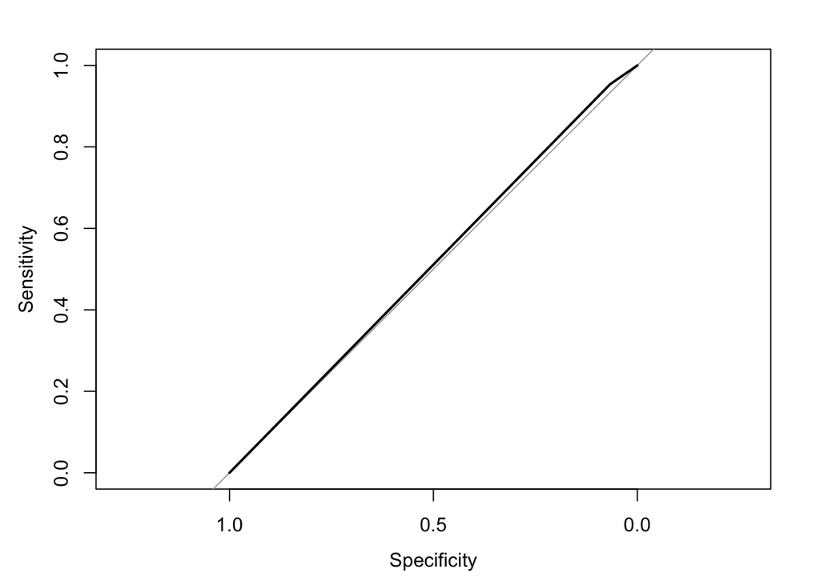

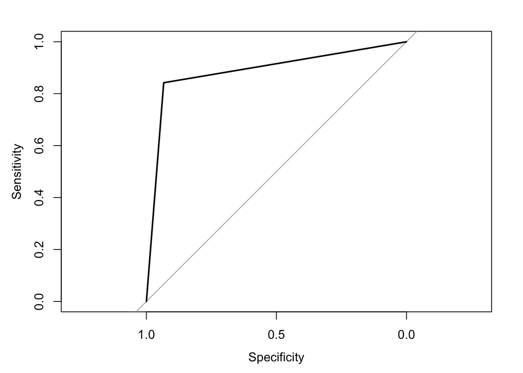

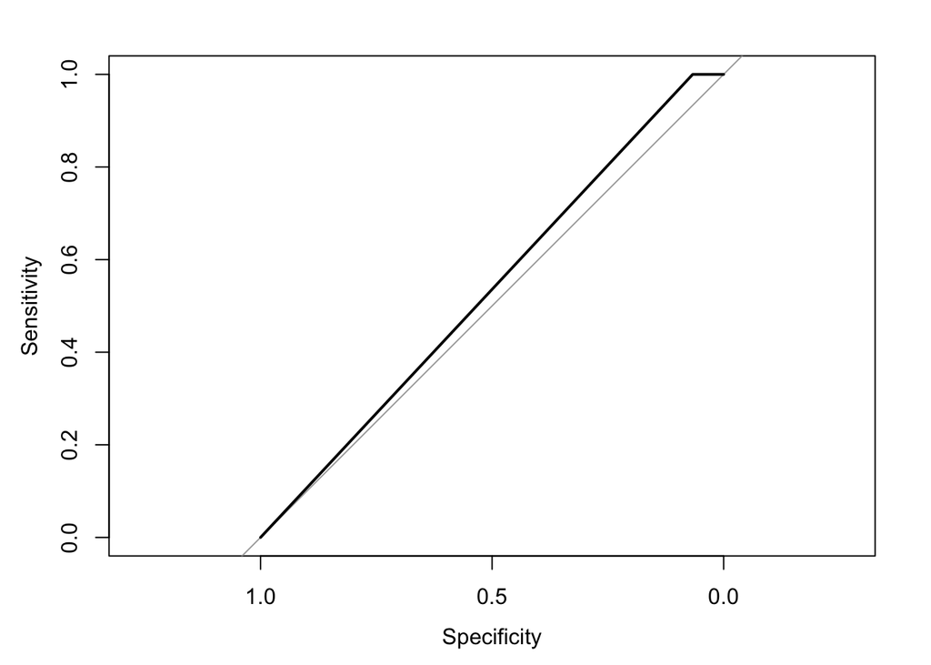

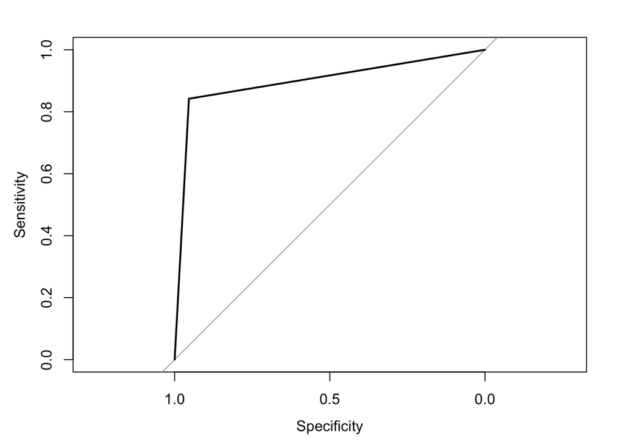

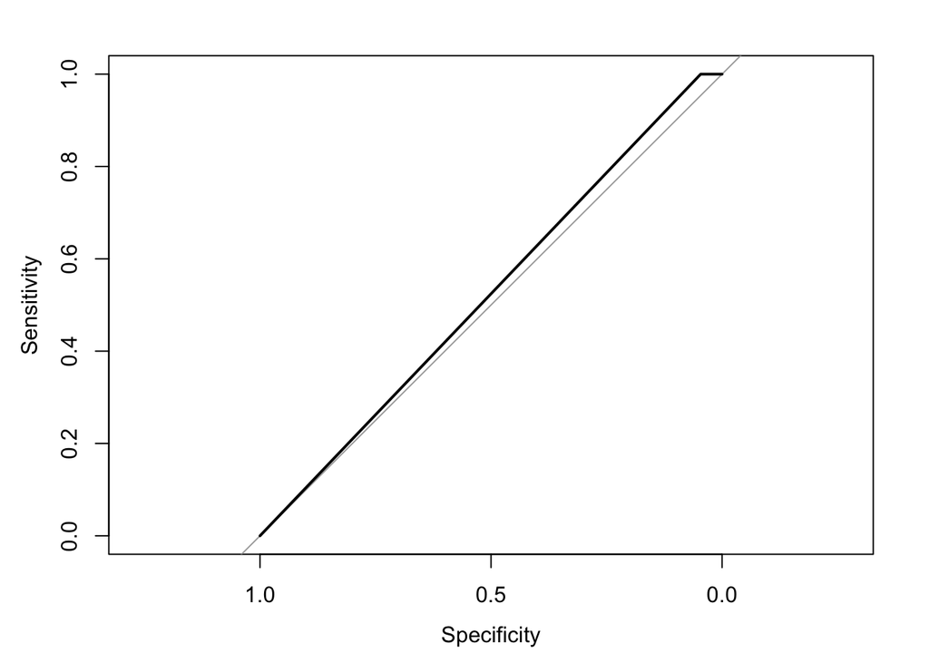

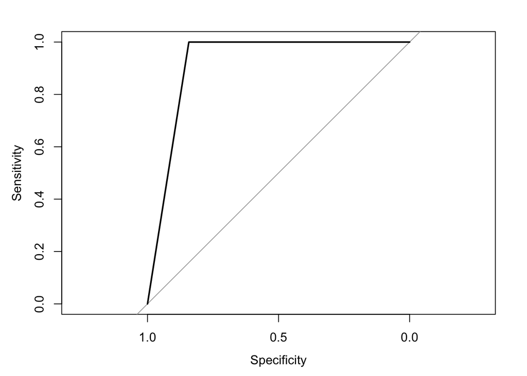

```
##
## Call:
## multiclass.roc.default(response = data$Tumor, predictor = ifelse(Tumor_data_fitted_prob[,     "3"] >= 0.35, 0, 1), plot = TRUE)
##
## Data: ifelse(Tumor_data_fitted_prob[, "3"] >= 0.35, 0, 1) with 4 levels of data$Tumor: 1, 2, 3, 4.
## Multi-class area under the curve: 0.7122
```

```r
multiclass.roc(data$Tumor, ifelse(Tumor_data_fitted_prob[, '3'] >= .35, 0, 1), plot = TRUE)
```

##### Class4

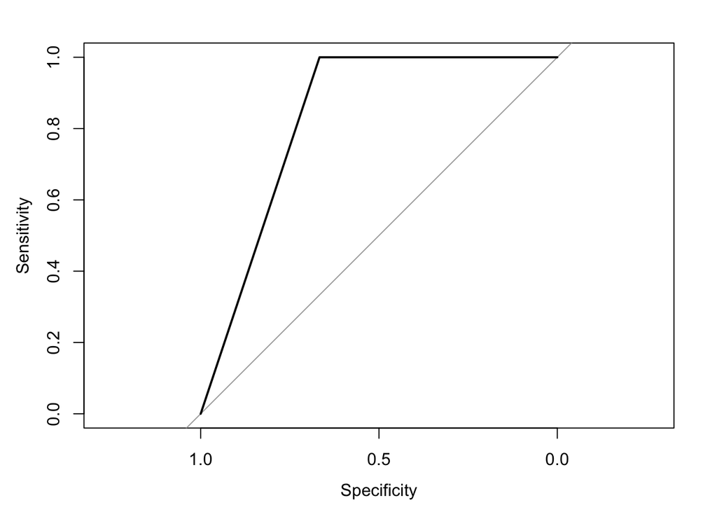

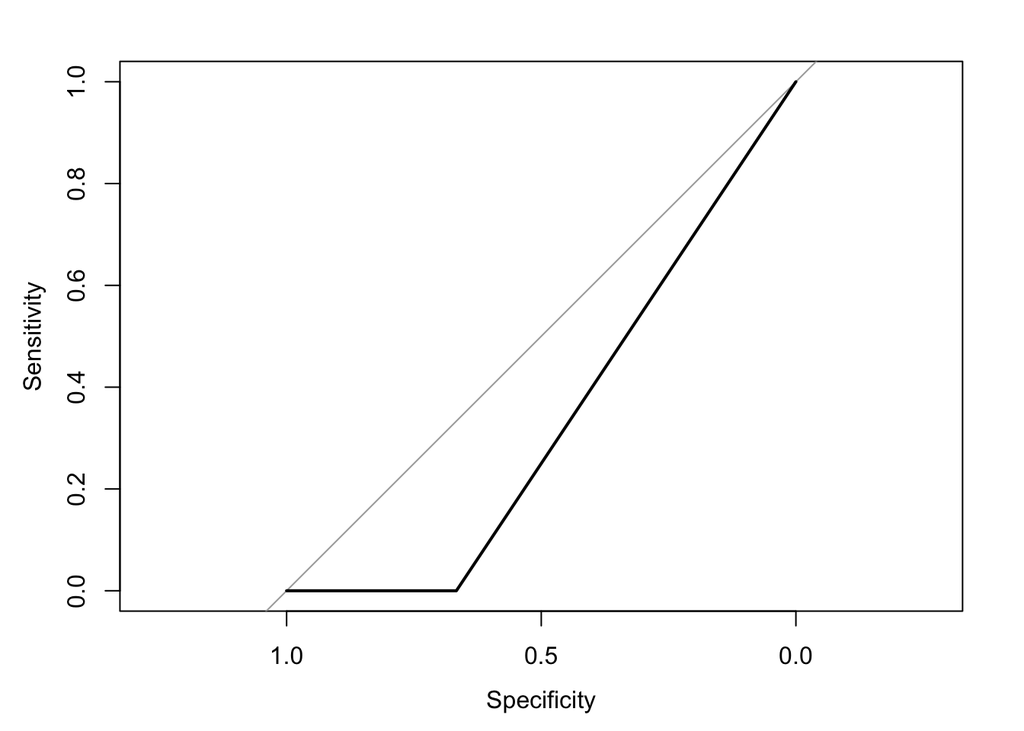

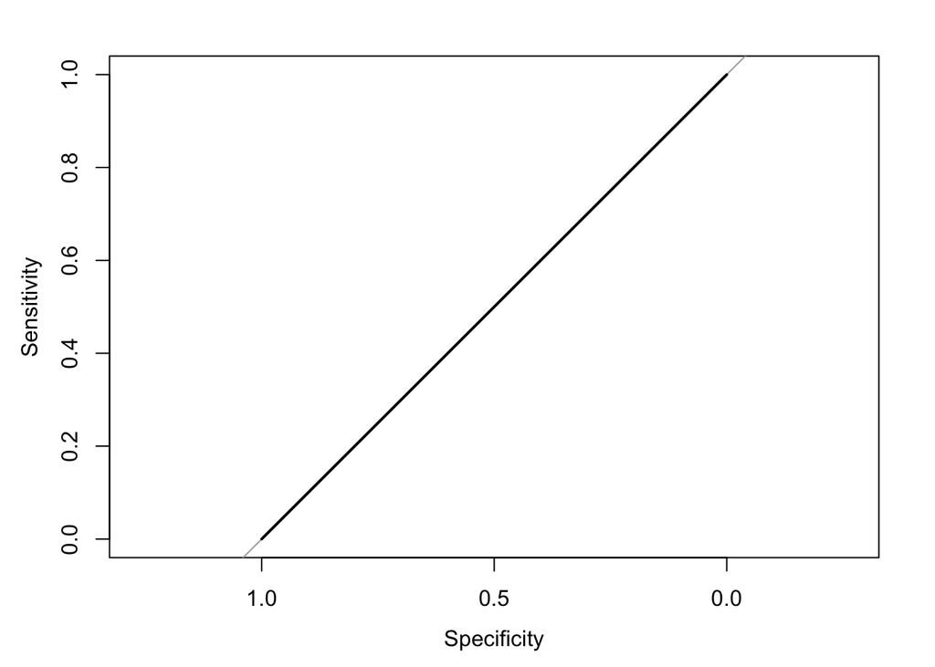

```
##
## Call:
## multiclass.roc.default(response = data$Tumor, predictor = ifelse(Tumor_data_fitted_prob[,     "4"] >= 0.35, 0, 1), plot = TRUE)
##
## Data: ifelse(Tumor_data_fitted_prob[, "4"] >= 0.35, 0, 1) with 4 levels of data$Tumor: 1, 2, 3, 4.
## Multi-class area under the curve: 0.75
```

```r
multiclass.roc(data$Tumor, ifelse(Tumor_data_fitted_prob[, '4'] >= .35, 0, 1), plot = TRUE)
```

#### Complexity Parameter (CP)

##### Complexity Parameter (CP) = 0.25

```
## Confusion Matrix and Statistics
##
##           Actual
## Prediction  1  2  3  4
##          1  0  0  0  0
##          2 15 65 19  6
##          3  0  0  0  0
##          4  0  0  0  0
##
## Overall Statistics
##
##                Accuracy : 0.619
##                  95% CI : (0.5191, 0.7121)
##     No Information Rate : 0.619
##     P-Value [Acc > NIR] : 0.5431
##
##                   Kappa : 0
##
##  Mcnemar's Test P-Value : NA
##
## Statistics by Class:
##
##                      Class: 1 Class: 2 Class: 3 Class: 4
## Sensitivity            0.0000    1.000    0.000  0.00000
## Specificity            1.0000    0.000    1.000  1.00000
## Pos Pred Value            NaN    0.619      NaN      NaN
## Neg Pred Value         0.8571      NaN    0.819  0.94286
## Prevalence             0.1429    0.619    0.181  0.05714
## Detection Rate         0.0000    0.619    0.000  0.00000
## Detection Prevalence   0.0000    1.000    0.000  0.00000
## Balanced Accuracy      0.5000    0.500    0.500  0.50000
```

##### Complexity Parameter (CP) = 0.1

```
## Confusion Matrix and Statistics
##
##           Actual
## Prediction  1  2  3  4
##          1 10  0  0  6
##          2  5 65 19  0
##          3  0  0  0  0
##          4  0  0  0  0
##
## Overall Statistics
##
##                Accuracy : 0.7143
##                  95% CI : (0.6179, 0.7982)
##     No Information Rate : 0.619
##     P-Value [Acc > NIR] : 0.02645
##
##                   Kappa : 0.37
##
##  Mcnemar's Test P-Value : NA
##
## Statistics by Class:
##
##                      Class: 1 Class: 2 Class: 3 Class: 4
## Sensitivity           0.66667   1.0000    0.000  0.00000
## Specificity           0.93333   0.4000    1.000  1.00000
## Pos Pred Value        0.62500   0.7303      NaN      NaN
## Neg Pred Value        0.94382   1.0000    0.819  0.94286
## Prevalence            0.14286   0.6190    0.181  0.05714
## Detection Rate        0.09524   0.6190    0.000  0.00000
## Detection Prevalence  0.15238   0.8476    0.000  0.00000
## Balanced Accuracy     0.80000   0.7000    0.500  0.50000
```

#### Minimum number of observations in any terminal

##### Minimum number of observations in any terminal = 15

```
## Confusion Matrix and Statistics
##
##           Actual
## Prediction  1  2  3  4
##          1 10  0  0  6
##          2  5 65 19  0
##          3  0  0  0  0
##          4  0  0  0  0
##
## Overall Statistics
##
##                Accuracy : 0.7143
##                  95% CI : (0.6179, 0.7982)
##     No Information Rate : 0.619
##     P-Value [Acc > NIR] : 0.02645
##
##                   Kappa : 0.37
##
##  Mcnemar's Test P-Value : NA
##
## Statistics by Class:
##
##                      Class: 1 Class: 2 Class: 3 Class: 4
## Sensitivity           0.66667   1.0000    0.000  0.00000
## Specificity           0.93333   0.4000    1.000  1.00000
## Pos Pred Value        0.62500   0.7303      NaN      NaN
## Neg Pred Value        0.94382   1.0000    0.819  0.94286
## Prevalence            0.14286   0.6190    0.181  0.05714
## Detection Rate        0.09524   0.6190    0.000  0.00000
## Detection Prevalence  0.15238   0.8476    0.000  0.00000
## Balanced Accuracy     0.80000   0.7000    0.500  0.50000
```

##### Minimum number of observations in any terminal = 5

```
## Confusion Matrix and Statistics
##
##           Actual
## Prediction  1  2  3  4
##          1 13  1  0  0
##          2  1 63  1  0
##          3  1  1 18  0
##          4  0  0  0  6
##
## Overall Statistics
##
##                Accuracy : 0.9524
##                  95% CI : (0.8924, 0.9844)
##     No Information Rate : 0.619
##     P-Value [Acc > NIR] : 1.251e-15
##
##                   Kappa : 0.915
##
##  Mcnemar's Test P-Value : NA
##
## Statistics by Class:
##
##                      Class: 1 Class: 2 Class: 3 Class: 4
## Sensitivity            0.8667   0.9692   0.9474  1.00000
## Specificity            0.9889   0.9500   0.9767  1.00000
## Pos Pred Value         0.9286   0.9692   0.9000  1.00000
## Neg Pred Value         0.9780   0.9500   0.9882  1.00000
## Prevalence             0.1429   0.6190   0.1810  0.05714
## Detection Rate         0.1238   0.6000   0.1714  0.05714
## Detection Prevalence   0.1333   0.6190   0.1905  0.05714
## Balanced Accuracy      0.9278   0.9596   0.9621  1.00000
```

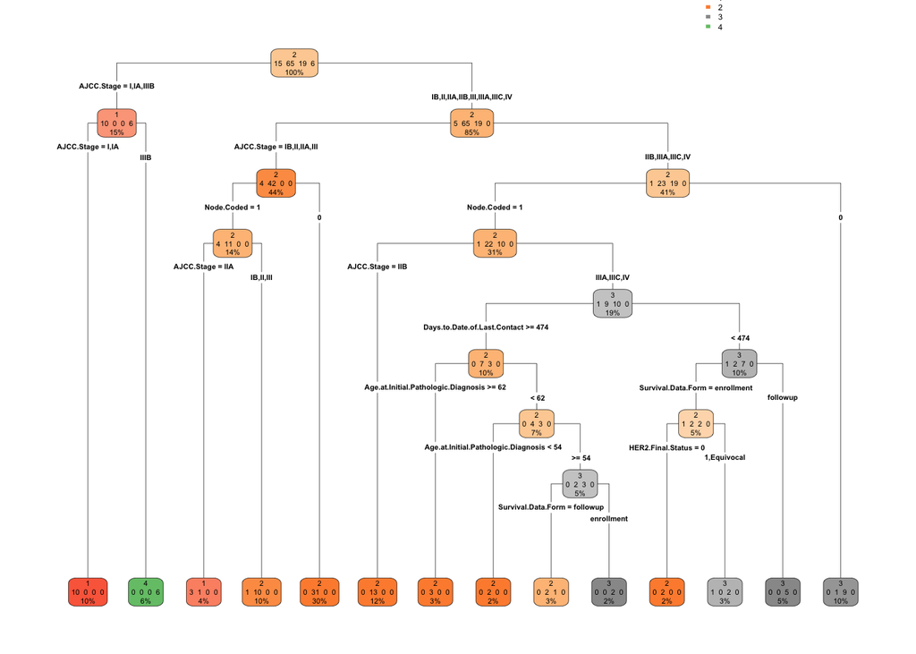

By reducing the number of observations per terminal to 5, we yield an accuracy of 0.9524.

```r
#21 Summarize what you learned for each model along the way and make recommendations to the world on how this could be used moving forward, being careful not to over promise.
```

From the first model regarding the PR variable, we learned that the most important variables were Days.to.Date.of.Last.Contact, AJCC.Stage, and OS.Time. We found that our model had a higher sensitivity value (0.8148) than specificity value (0.6471) and concluded that it is better at identifying subjects that are cancer-positive than negative. The accuracy of our first model was calculated to be 0.7333. From the AUC value and ROC curve, we determined that there is a 73.09% chance that our first model accurately identifies cancer based on the PR variable. By adjusting the minimum number of observations in any terminal to 5, the sensitivity and specificity values were maximized and the model’s prediction accuracy improved to 0.8857.

While our models were overall successful and can help with diagnoses, it is important to acknowledge that the models aren’t perfect. While it is impossible to create a perfect model, building these models with larger datasets would make them more successful.